# Functions and loops lab

Casey O’Hara

10/28/2019

# Why functions?

- They make it easy to do a task over and over without copy-and-pasting it
- They wrap a chunk of complicated code into an object with a helpful name

## Making a basic function

First let’s make a very straightforward and simple function. This one takes a number, and adds one.

```r
add_one <- function(x) {
  y <- x + 1
}

z <- add_one(x = 2) ### yay!
zz <- add_one(3:7) ### works on vectors too!
```

Let’s add an argument. Best practice: an explicit `return()` at the end:

```r
add_some <- function(x, a = 1) {
  y <- x + a
  print('yay!')
  return(y)
}

z <- add_some(2)
```

```
## [1] "yay!"
```

```r
zz <- add_some(3:7, 1000) # or add_some(3:7, a = 1000)
```

```
## [1] "yay!"
```

Note: a good practice is to name functions using a verb, since they do a thing, i.e. add_some, calc_thing, etc. (consider tidyverse functions)

## Now something useful!

Let’s make a function to calculate the mean of a vector of values. First, let’s create a vector values we can use for testing. We’ll use `rnorm()` to generate a pseudo-random set of numbers as a working sample, with a known mean and standard deviation.

For reproducibility, we can set a “random seed” so we’ll all get the same vector of “random” numbers.

```r
set.seed(12345) ### can be any number; as long as you set this you should get
  ### the same "random" results every time you run it.
test_vec <- rnorm(100, mean = 1, sd = 1)

### see what the built-in functions say:
mean(test_vec)
```

```
## [1] 1.245197
```

```r
sd(test_vec)
```

```
## [1] 1.114731
```

```r
### one way to calculate the mean
n <- length(test_vec)
mymean <- sum(test_vec) / n
mymean
```

```
## [1] 1.245197
```

We can turn that basic code into a basic function. Give it a verb name.

```r
calc_mean <- function(x) {
  n <- length(x)
  mean_x <- sum(x) / n
  return(mean_x)
}

calc_mean(test_vec)
```

```
## [1] 1.245197
```

### Anatomy of a function

The `calc_mean` is an object - before we made dataframes and vectors, this time the object is a function. Look at the function, just like you’d look at an object:

```r
calc_mean
```

```
## function(x) {
##   n <- length(x)
##   mean_x <- sum(x) / n
##   return(mean_x)
## }
```

You can try that with other R functions, but the heavy duty ones (e.g. tidyverse functions) will usually be implemented in a different way.

- `function()` is a function that creates functions. Very meta.
- Inside the arguments for `function(...)`, we put in what variables the function will need to know to perform its duties.
- after the arguments, we define the actual function by providing an executable bit of code; a single line would work, but anything more than that, we need to hold it all inside curly braces so it operates as one complete piece.
- at the end, R gives back a value; best practice is to explicitly say `return()` to avoid any ambiguity.

### Environments

Most of the time we’re working in the “global environnment” (see the “Environment” tab).

When you execute a function, R creates a new environment, like a pocket universe, separate from the global env. The arguments (in this case, `x`) are a window through which you can pass info to that new universe. The `return(...)` is a window through which the function can pass the result from that universe back to the global environment.

```r
add_one ### check our function
```

```
## function(x) {
##   y <- x + 1
## }
## <bytecode: 0x5619b66fbb68>
```

```r
x <- 100
y <- 200
z <- add_one(x = 8)
x
```

```
## [1] 100
```

```r
y
```

```
## [1] 200
```

Note that changes to variables inside the function are NOT communicated back to the global environment. This is a good thing!

A well written function should only communicate with the global environment through those windows - and otherwise cannot affect anything in the global environment. Once the function finishes, it returns its value and then that pocket universe disappears forever.

## Improving the basic function

A well written function should anticipate when a user might have imperfect data. Error checks or additional arguments can be helpful. When might our `calc_mean()` function break down?

```r
calc_mean(1:10) ### OK
calc_mean(x = 1:10) ### OK
calc_mean(y = 1:10) ### function doesn't know what to do with y
calc_mean() ### function doesn't know what x is, and can't compute
calc_mean(x = c(1, 2, 3, 4, NA))
```

### Let’s update `calc_mean()` to deal with `NA`s.

First let’s make a test vector with some `NA`s. (Also, let’s learn about indexing to access specific elements in a vector). Use “index” numbers to tell which elements of the vector to change.

```r
test_vec_w_NA <- test_vec
test_vec_w_NA[5] <- NA
test_vec_w_NA[10:15] <- NA
test_vec_w_NA[c(20, 22, 24)] <- NA

test_vec_w_NA
```

```
##   [1]  1.58552882  1.70946602  0.89069669  0.54650283          NA
##   [6] -0.81795597  1.63009855  0.72381589  0.71584026          NA
##  [11]          NA          NA          NA          NA          NA
##  [16]  1.81689984  0.11364248  0.66842241  2.12071265          NA
##  [21]  1.77962192          NA  0.35567157          NA -0.59770952
##  [26]  2.80509752  0.51835264  1.62037980  1.61212349  0.83768902
##  [31]  1.81187318  3.19683355  3.04919034  2.63244564  1.25427119
##  [36]  1.49118828  0.67591342 -0.66205024  2.76773385  1.02580105
##  [41]  2.12851083 -1.38035806 -0.06026555  1.93714054  1.85445172
##  [46]  2.46072940 -0.41309878  1.56740325  1.58318765 -0.30679883
##  [51]  0.45961393  2.94769266  1.05359027  1.35166284  0.32902346
##  [56]  1.27795369  1.69117127  1.82379533  3.14506502 -1.34694398
##  [61]  1.14959198 -0.34253148  1.55330308  2.58996284  0.41312041
##  [66] -0.83237731  1.88813943  2.59348847  1.51685467 -0.29567168
##  [71]  1.05461558  0.21535063 -0.04935282  3.33051196  2.40270538
##  [76]  1.94260085  1.82625829  0.18845951  1.47624828  2.02125841
##  [81]  1.64538307  2.04314355  0.69563089  3.47711092  1.97122067
##  [86]  2.86709918  1.67204247  0.69204662  1.53652372  1.82487007
##  [91]  0.03609852  0.14491749  2.88694694  0.60818063  0.01936705
##  [96]  1.68733210  0.49495648  3.15771982  0.40020244  0.30545331
```

```r
calc_mean(test_vec_w_NA)
```

```
## [1] NA
```

What do we need to do to make our function work with `NA`s?

- design in an na.rm argument to allow the user to decide whether to exclude `NA`s.
- adjust code to use `na.rm`.

#### First, quick thing with vectors:

How can we find and exclude `NA` values from a vector?

```r
z <- c(1:5, NA) ### set up a vector with numbers and an NA
is.na(z)
```

```
## [1] FALSE FALSE FALSE FALSE FALSE  TRUE
```

```r
!is.na(z)
```

```
## [1]  TRUE  TRUE  TRUE  TRUE  TRUE FALSE
```

```r
### We want to keep the elements of z that are not NA
zz <- z[!is.na(z)]
```

Now that we know how to drop NAs, let’s write a new function:

```r
calc_mean2 <- function(x, na.rm = TRUE) {
  if(na.rm == TRUE) { ### drop NAs
    x <- x[!is.na(x)]
  }

  n <- length(x)
  mymean <- sum(x) / n
  return(mymean)
}

calc_mean2(test_vec_w_NA)
```

```
## [1] 1.253227
```

```r
mean(test_vec_w_NA, na.rm = TRUE) ### compare to base R function
```

```
## [1] 1.253227
```

We can use this function anywhere we might use the regular `base::mean()`. All it needs is a vector, which can even be a column from a dataframe!

```r
data(iris) ### load the built-in data
iris_mean <- iris %>%
  janitor::clean_names() %>%
  group_by(species) %>%
  summarize(mean_sepal_w = calc_mean2(sepal_width),
            mean_sepal_l = calc_mean2(sepal_length))
```

## Using our function inside another function

Let’s write a function to calculate standard deviation. The formula for this is:
$$s(x) = \sqrt{\text{Var}(x)} = \sqrt{\frac{1}{n-1} \sum_{i=1}^n(x - \bar x)^2}$$

```r
calc_sd <- function(x, na.rm = TRUE) {
  if(na.rm) {
    ### drop NAs
    x <- x[!is.na(x)]
  }

  n <- length(x)
  mean_x <- calc_mean2(x)
  var_x <- 1/(n - 1) * sum((x - mean_x)^2)
  sd_x <- sqrt(var_x) ### sd is square root of variance
  return(sd_x)
}

sd(test_vec_w_NA, na.rm = TRUE) ### base R function
```

```
## [1] 1.127493
```

```r
calc_sd(test_vec_w_NA) ### yay! same result
```

```
## [1] 1.127493
```

Every time you use a function, consider: what are the arguments? what are the defaults (and why did they choose those)? what is the returned value?

# Why loops?

Sometimes you want to do a thing many many times, i.e., iterate. Loops are one way to do this, especially if you have a vector of values and you’d like to calculate something based on those values.

## Super basic loops

```r
times <- 10

for (i in 1:times) {
  print(i + 1)
}
```

```
## [1] 2
## [1] 3
## [1] 4
## [1] 5
## [1] 6
## [1] 7
## [1] 8
## [1] 9
## [1] 10
## [1] 11
```

```r
x <- 1
for(j in 1:times) {
  x <- x + j
  print(x)
}
```

```
## [1] 2
## [1] 4
## [1] 7
## [1] 11
## [1] 16
## [1] 22
## [1] 29
## [1] 37
## [1] 46
## [1] 56
```

```r
for(k in 1:times) {
  print("hello world!")
}
```

```
## [1] "hello world!"
## [1] "hello world!"
## [1] "hello world!"
## [1] "hello world!"
## [1] "hello world!"
## [1] "hello world!"
## [1] "hello world!"
## [1] "hello world!"
## [1] "hello world!"
## [1] "hello world!"
```

## Loops for simulating model results

A standard die has equal chances to land on each of its six sides. This is a uniform distribution.

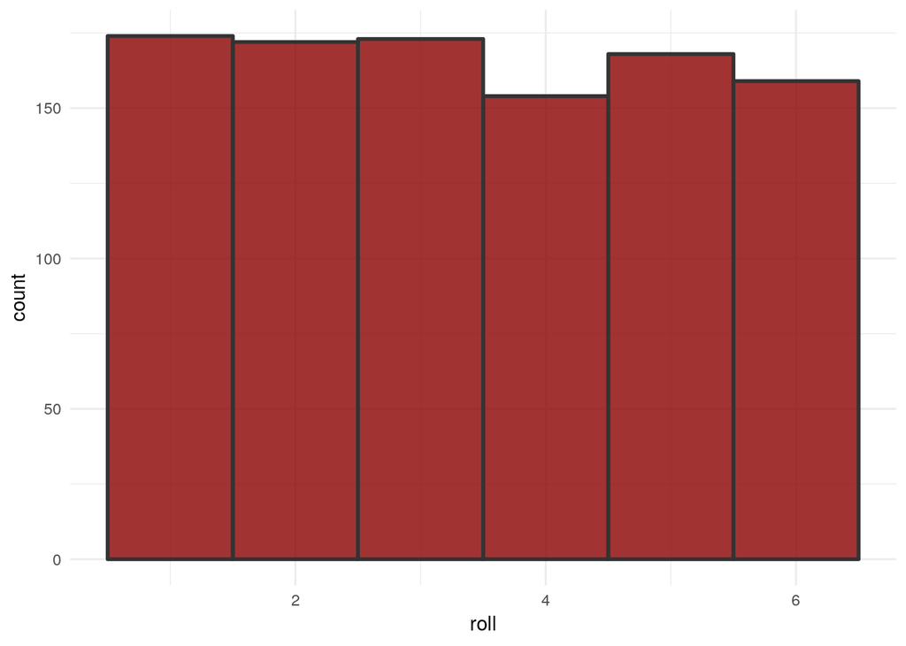

```r
### explore the distribution of die rolls
die_rolls <- data.frame(roll = sample(1:6, size = 1000, replace = TRUE))

ggplot(die_rolls, aes(x = roll)) +
  geom_histogram(bins = 6, color = 'grey20', fill = 'darkred',
                 size = 1, alpha = .8) +
  theme_minimal()
```

OK cool, now let’s make a loop to calculate a bunch of simulations. Here let’s simulate rolling a die 20 times, and calculate the mean and standard deviation. Then we will repeat that experiment a bunch of times, i.e. iterate for many simulations.

```r
### set up for a lot of simulations
sims <- 10000

### initialize empty results vectors that I will populate in the loop
mean_results <- vector('numeric', length = sims)
sd_results <- vector('numeric', length = sims)

for(i in 1:sims) {
  rolls_vec <- sample(x = 1:6, size = 20, replace = TRUE)
  sim_mean <- calc_mean2(rolls_vec)
  mean_results[i] <- sim_mean
  sd_results[i] <- calc_sd(rolls_vec)
}
```

Let’s put the results into a dataframe and do some plots.

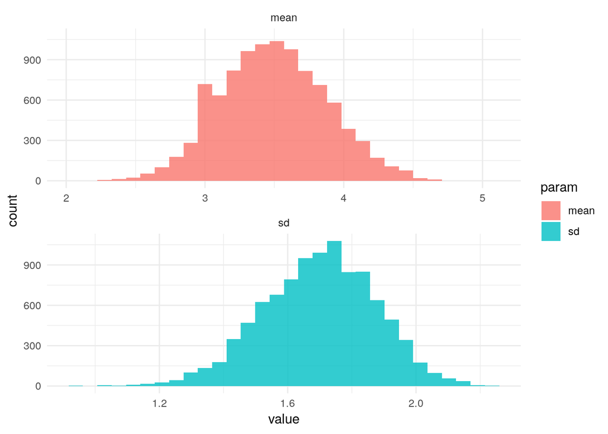

```r
results_df <- data.frame(sim = 1:sims,
                         mean = mean_results,
                         sd   = sd_results) %>%
  pivot_longer(names_to = 'param', values_to = 'value', -sim)

ggplot(results_df, aes(x = value, fill = param)) +
  geom_histogram(alpha = .8) +
  theme_minimal() +
  facet_wrap( ~ param, nrow = 2, scales = 'free_x')
```

If the probability distribution for a die roll is uniform, why are these looking like normal distributions? Central Limit Theorem!